# RNAseq_Analysis

Tzu L. Phang

April 29, 2015

# 1 Background

This tutorial outlines a transcriptomic RNAseq analysis workflow module conducted in my course; [R + Biocondcutor data analysis course (BIOS6660)](http://compbio.ucdenver.edu/ccp/Hunter_lab/Phang/Page%2012/index.html) at the [Anschutz Medical Campus, University of Colorado, Denver](http://www.ucdenver.edu/anschutz/Pages/landing.aspx). We use a dataset from a collaborator, [Dr. Eric Schmidt](http://www.ucdenver.edu/academics/colleges/medicalschool/departments/medicine/Pulmonary/Pages/Eric-Schmidt-MD.aspx) (PI), to investigate pulmonary endothelial glycocalyx recovery after sepsis. To learn more about RNA-seq technology, please refer to these 2 early publications. (see Wang 2011 and Pepke (2009))

## 1.1 Analysis Goals

The PI is interested in identifying differentially expressed genes comparing CLP vs. Sham in a mouse model.

# 2 Experimental Design

The dataset contains two comparison groups; CLP and Sham, with a sample size of 3 for each. Since RNAseq dataset is typically very large, we have extracted only Chromosome 19 from each sample, using the [seqtk tool](http://ged.msu.edu/angus/tutorials-2013/seqtk_tools.html) to ease the computational process on the students’ personal computer, which are mostly less powerful then server-class computers. The goal of this course is to enable students to perform data analysis using their owned resources.

## 2.1 Experimental Descriptive File

First, we will read in the experimental descriptive data file which lists the sample names and summarizes the grouping of each samples.

```r
## Read in descriptive data file
targets = read.table('./data/targets.txt', header = T)
## printing file table
knitr::kable(targets)
```

| FileName | SampleName | Factor | Factor_long |
| --- | --- | --- | --- |
| CLP_lung_48h_rep1_chr19_read1.fastq | CLP_lung_48h_rep1 | CLP | CLP_lung_48h_rep1 |
| CLP_lung_48h_rep2_chr19_read1.fastq | CLP_lung_48h_rep2 | CLP | CLP_lung_48h_rep2 |
| CLP_lung_48h_rep3_chr19_read1.fastq | CLP_lung_48h_rep3 | CLP | CLP_lung_48h_rep3 |
| Sham_lung_48h_rep1_chr19_read1.fastq | Sham_lung_48h_rep1 | Sham | Sham_lung_48h_rep1 |
| Sham_lung_48h_rep2_chr19_read1.fastq | Sham_lung_48h_rep2 | Sham | Sham_lung_48h_rep2 |
| Sham_lung_48h_rep3_chr19_read1.fastq | Sham_lung_48h_rep3 | Sham | Sham_lung_48h_rep3 |

It seems like we have a total of 6 FASTQ files and 2 experimental grouping (CLP vs. Sham) in mouse sample

# 3 Quality Control of FASTQ Files

## 3.1 FASTQ QC with `seqTools`

We used a [Bioconductor](http://www.bioconductor.org) tool; `seqTools` to assess the quality of FASTQ file. Note that the `seqTools` package document a details description of the FASTQ format, check it out.

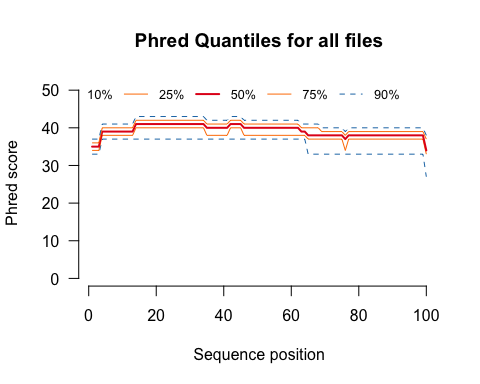

```r
library(seqTools)
filenames = c(
  './data/CLP_lung_48h_rep1_chr19_read1.fastq',
  './data/CLP_lung_48h_rep2_chr19_read1.fastq',
  './data/CLP_lung_48h_rep3_chr19_read1.fastq',
  './data/Sham_lung_48h_rep1_chr19_read1.fastq',
  './data/Sham_lung_48h_rep2_chr19_read1.fastq',
  './data/Sham_lung_48h_rep3_chr19_read1.fastq'
  )
fq = fastqq(filenames = filenames, probeLabel = c(paste('CLP',1:3, sep = '-'), paste('Sham',4:6,sep='-')))
pdf(file = './qc/seqTools.fastq.qc.pdf')
plotPhredQuant(fq, 1)
plotPhredQuant(fq, 2)
plotPhredQuant(fq, 3)
plotPhredQuant(fq, 4)
plotPhredQuant(fq, 5)
plotPhredQuant(fq, 6)
dev.off()

plotMergedPhredQuant(fq, main = 'Phred Quantiles for all files')
```

## 3.2 Non-R Approach 1: FASTQC

[FASTQC](http://www.bioinformatics.babraham.ac.uk/projects/fastqc/) is a Graphic User Interface (GUI) tool designed to perform quality assessment of FASTQ files

```r
fastq.list = c(
  './data/CLP_lung_48h_rep1_chr19_read1.fastq',
  './data/CLP_lung_48h_rep2_chr19_read1.fastq',
  './data/CLP_lung_48h_rep3_chr19_read1.fastq',
  './data/Sham_lung_48h_rep1_chr19_read1.fastq',
  './data/Sham_lung_48h_rep2_chr19_read1.fastq',
  './data/Sham_lung_48h_rep3_chr19_read1.fastq'
)
for(i in 1:length(fastq.list)){

  output.dir.o = '-o'
  output.dir = './qc/'


    args.cond = c(
    output.dir.o, output.dir,
        fastq.list[i]
    )
    system2('fastqc', args = args.cond, wait = F)

}
```

## 3.3 Non-R Approach 2: RSeQC

[RSeQC](http://rseqc.sourceforge.net) is an RNA-seq quality control package written in Python. This Python package also include many QC utilities for SAM/BAM files.

# 4 Mapping FASTQ to genome

## 4.1 Mapping with QuasR

We will be using `QuasR` Bioconductor package to map the FASTQ files onto the mouse genome to determine the read genomic coordinate. `QuasR` is an extremely versatile NGS mapping and postprocessing pipeline for RNA-seq. It uses `Rbowtie` for upgapped alignments and SpliceMap for spliced alignments

Note: `QuasR` is an intelligent package; if it finds BAM files already exists from the previous runs, it will not generate the file again. If we want to do a new run, we need to delete everything in the “result” folder …

Note: It is best to put `eval=FALSE` before running `knitr` to avoid long mapping processes.

```r
library(QuasR)
targets = read.table("./data/targets.txt", header = T)
write.table(targets[,1:2], 'data/QuasR_samples.txt', row.names=F, quote=F, sep='\t')
sampleFile = "./data/QuasR_samples.txt"
genomeFile = "./data/Mouse.chromosome.19.fa"
results = "./result"
cl = makeCluster(10)

## Single command to index reference, align all samples and generate BAM files
proj <- qAlign(sampleFile, genome=genomeFile, maxHits=1, splicedAlignment=T, alignmentsDir=results, clObj=cl, cacheDir=results)
# Note: splicedAlignment should be set to TRUE when the reads are >=50nt long
alignstats <- alignmentStats(proj) # Alignment summary report
#knitr::kable(alignstats)
```

### 4.1.1 Alignment Summary

```r
library(ShortRead); library(Rsamtools)
## Extract bam file names:
bam.filenames = proj@alignments$FileName

Nreads <- countLines(dirPath="./data/", pattern=".fastq$")/4
bfl <- BamFileList(bam.filenames, yieldSize=50000, index=character())
Nalign <- countBam(bfl, param=ScanBamParam(flag=scanBamFlag(isUnmappedQuery=F)))
#(read_statsDF <- data.frame(FileName=names(Nreads), Nreads=Nreads, Nalign=Nalign$records, Perc_Aligned=Nalign$records/Nreads*100))
#write.table(read_statsDF, "./result/read_statsDF.txt", row.names=FALSE, quote=FALSE, sep="\t")

## Remove rownames before display
rownames(read_statsDF) = c()
knitr::kable(read_statsDF)
```

| FileName | Nreads | Nalign | Perc_Aligned |
| --- | --- | --- | --- |
| CLP_lung_48h_rep1_chr19_read1.fastq | 1290664 | 1168495 | 90.53441 |
| CLP_lung_48h_rep2_chr19_read1.fastq | 1324913 | 1200681 | 90.62338 |
| CLP_lung_48h_rep3_chr19_read1.fastq | 1467134 | 1323209 | 90.19006 |
| Sham_lung_48h_rep1_chr19_read1.fastq | 2094335 | 1905972 | 91.00607 |
| Sham_lung_48h_rep2_chr19_read1.fastq | 1666375 | 1507205 | 90.44813 |
| Sham_lung_48h_rep3_chr19_read1.fastq | 1955572 | 1783449 | 91.19833 |

## 4.2 Mapping with `bowtie2` using the terminal

For Mac and Linux users, if you are lucky enough have the proper computational resources, and have installed bowtie2 in your system. Here are some codes for running `bowtie2` from R using the `system2` function.

```r
fastq.list = c(
  './data/CLP_lung_48h_rep1_chr19_read1.fastq',
  './data/CLP_lung_48h_rep2_chr19_read1.fastq',
  './data/CLP_lung_48h_rep3_chr19_read1.fastq',
  './data/Sham_lung_48h_rep1_chr19_read1.fastq',
  './data/Sham_lung_48h_rep2_chr19_read1.fastq',
  './data/Sham_lung_48h_rep3_chr19_read1.fastq'
)

#for(i in 1){
for(i in 1:length(fastq.list)){

      cat('Doing ', fastq.list[i], ' now .............................\n\n')

      # Bowtie2 mapping ---------------------------------------------------------

      process.p = '-p'
      process.n = '10'
      genome.x = '-x'
      genome.path = '/Volumes/Tzu_Pegasus/Tzu_iMac_Documents/MyGenome/Mus_musculus_UCSC_mm9/Mus_musculus/UCSC/mm9/Sequence/Bowtie2Index/genome'
      input.U = '-U'
      input.file = fastq.list[i]
      output.S = '-S'
      if(length(grep('fastq.gz', input.file))){
        output.file = gsub('.fastq.gz', '.sam', input.file)
      }else if(length(grep('fastq', input.file))){
        output.file = gsub('.fastq', '.sam', input.file)
      }
      output.file = gsub('./data/', './bowtie2_results/', output.file)


      args.cond = c(
          process.p, process.n,
          genome.x, genome.path,
          input.U, input.file,
          output.S, output.file
        )

      cat('Running bowtie2 now ............................... \n')
      ptm = proc.time()
      system2('bowtie2', args = args.cond)
      time.ellapsed = proc.time() - ptm
      cat('Ellapsed time is ' , time.ellapsed[3]/60, ' minutes\n')


      # samtools view
      samtools.comd = 'view'
      samtools.input.bS = '-bS'
      samtools.input = output.file
      samtools.direct = '>'
      samtools.output = gsub('.sam', '.bam', samtools.input)

      args.cond = c(
          samtools.comd,
          samtools.input.bS, samtools.input,
          samtools.direct,
          samtools.output
        )
      cat('Running samtools view now ............................... \n')
      ptm = proc.time()
      system2('samtools', args = args.cond)
      time.ellapsed = proc.time() - ptm
      cat('Ellapsed time is ' , time.ellapsed[3]/60, ' minutes\n')

      # samtools sort
      samtools.comd = 'sort'
      samtools.input = samtools.output
      samtools.output = gsub('.bam', '_sorted', samtools.input)

      args.cond = c(
        samtools.comd,
        samtools.input,
        samtools.output
      )

      cat('Running samtools sort now ............................... \n')
      ptm = proc.time()
      system2('samtools', args = args.cond)
      time.ellapsed = proc.time() - ptm
      cat('Ellapsed time is ' , time.ellapsed[3]/60, ' minutes\n')


      # samtools index
      samtools.comd = 'index'
      samtools.input = paste(samtools.output,'.bam', sep = '')

      args.cond = c(
        samtools.comd,
        samtools.input
      )

      cat('Running samtools index now ............................... \n')
      ptm = proc.time()
      system2('samtools', args = args.cond)
      time.ellapsed = proc.time() - ptm
      cat('Ellapsed time is ' , time.ellapsed[3]/60, ' minutes\n')



}
```

## 4.3 FASTQ Quality Report revisited by `QuasR`

The following shows how to create read quality reports with `QuasR`’s qQCReport function or with the custom seeFastq function from UC Rivierside, [Dr. Girke group](http://manuals.bioinformatics.ucr.edu/home)

```r
qQCReport(proj, pdfFilename="./qc/qc_report.pdf")
source("http://faculty.ucr.edu/~tgirke/Documents/R_BioCond/My_R_Scripts/fastqQuality.R")
myfiles <- paste0("data/", targets$FileName); names(myfiles) <- targets$SampleName
fqlist <- seeFastq(fastq=myfiles, batchsize=50000, klength=8)
pdf("./qc/fastqReport.pdf", height=18, width=4*length(myfiles)); seeFastqPlot(fqlist); dev.off()
```

# 5 Gene Read Count

## 5.1 Annotations of Transcriptome

Storing annotation ranges in TranscriptDb databases makes many operations more robust and convenient

```r
library(GenomicFeatures)
txdb <- makeTranscriptDbFromGFF(file="./data/genes.gtf",
                                format="gtf",
                                dataSource="mm9",
                                species="Mus musculus")
saveDb(txdb, file="./data/mouse_annotation.sqlite")
txdb <- loadDb("./data/mouse_annotation.sqlite")
eByg <- exonsBy(txdb, by="gene")
```

## 5.2 Generate Read Count Table

The gene signal was obtained by overlapping sequened reads onto the pre-defined gene region ranges. The resulting count table was further filtered to remove genes with zero counts.

```r
samples <- as.character(targets$Factor_long)
samples = gsub('_lung_48h_','.',samples)
samplespath <- bam.filenames
names(samplespath) <- samples
countDF <- data.frame(row.names=names(eByg))
for(i in samplespath) {
  aligns <- readGAlignmentsFromBam(i) # Substitute next two lines with this one.
  seqnames(aligns) = rep('chr19', length(aligns))
  counts <- countOverlaps(eByg, aligns, ignore.strand=TRUE)
  countDF <- cbind(countDF, counts)
}


colnames(countDF) <- samples

## Remove row with all zeros
row.sum = rowSums(countDF)
chr19.countDF = countDF[row.sum != 0,]

knitr::kable(chr19.countDF[1:4,], align = 'c')
```

|  | CLP.rep1 | CLP.rep2 | CLP.rep3 | Sham.rep1 | Sham.rep2 | Sham.rep3 |
| --- | --- | --- | --- | --- | --- | --- |
| 1110059E24Rik | 2 | 0 | 1 | 1 | 1 | 3 |
| 1500015L24Rik | 1 | 4 | 0 | 2 | 2 | 5 |
| 1500017E21Rik | 0 | 1 | 0 | 2 | 0 | 1 |
| 1700001K23Rik | 40 | 21 | 33 | 34 | 28 | 29 |

```r
write.table(chr19.countDF, "./result/chr19_countDF", quote=FALSE, sep="\t", col.names = NA)
countDF <- read.table("./result/chr19_countDF")
```

## 5.3 Simple RPKM Normalization

RPKM: reads per kilobase of exon model per million mapped reads

```r
returnRPKM <- function(counts, gffsub) {
  geneLengthsInKB <- sum(width(reduce(gffsub)))/1000 # Length of exon union per gene in kbp
  millionsMapped <- sum(counts)/1e+06 # Factor for converting to million of mapped reads.
  rpm <- counts/millionsMapped # RPK: reads per kilobase of exon model.
  rpkm <- rpm/geneLengthsInKB # RPKM: reads per kilobase of exon model per million mapped reads.
  return(rpkm)
}
countDFrpkm <- apply(countDF, 2, function(x) returnRPKM(counts=x, gffsub=eByg[rownames(countDF)]))

knitr::kable(countDFrpkm[1:4,], align = 'c')
```

|  | CLP.rep1 | CLP.rep2 | CLP.rep3 | Sham.rep1 | Sham.rep2 | Sham.rep3 |
| --- | --- | --- | --- | --- | --- | --- |
| 1110059E24Rik | 1.779027 | 0.000000 | 0.84371 | 0.5254325 | 0.6985178 | 1.6985821 |
| 1500015L24Rik | 1.632680 | 6.627559 | 0.00000 | 1.9288369 | 2.5642245 | 5.1961767 |
| 1500017E21Rik | 0.000000 | 0.484245 | 0.00000 | 0.5637247 | 0.0000000 | 0.3037284 |
| 1700001K23Rik | 104.116816 | 55.471850 | 81.47334 | 52.2762243 | 57.2326512 | 48.0475975 |

### 5.3.1 Hierarchical Clustering

QC check of the sample reproducibility by computing a correlating matrix and plotting it as a tree. Note: the plotMDS function from edgeR is a more robust method for this task.

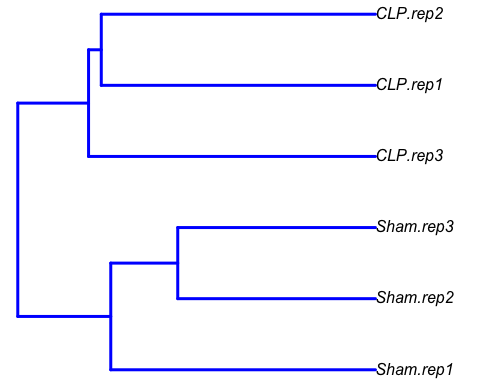

```r
library(ape)
d <- cor(countDFrpkm, method="spearman")
hc <- hclust(dist(1-d))
plot.phylo(as.phylo(hc), type="p", edge.col=4, edge.width=3, show.node.label=TRUE, no.margin=TRUE)
```

As expected, CLP and Sham samples clustered together respectively

# 6 Identification of DEGs with various methods

## 6.1 Identify DEGs with Simple Fold Change Method

```r
## Compute mean values for replicates
source("http://faculty.ucr.edu/~tgirke/Documents/R_BioCond/My_R_Scripts/colAg.R")
countDFrpkm_mean <- colAg(myMA=countDFrpkm, group=c(1,1,1,2,2,2), myfct=mean)
knitr::kable(countDFrpkm_mean[1:4,])
```

|  | CLP.rep1_CLP.rep2_CLP.rep3 | Sham.rep1_Sham.rep2_Sham.rep3 |
| --- | --- | --- |
| 1110059E24Rik | 0.8742456 | 0.9741774 |
| 1500015L24Rik | 2.7534129 | 3.2297461 |
| 1500017E21Rik | 0.1614150 | 0.2891510 |
| 1700001K23Rik | 80.3540010 | 52.5188243 |

```r
## Log2 fold change
countDFrpkm_mean <- cbind(countDFrpkm_mean, log2ratio=log2(countDFrpkm_mean[,2]/countDFrpkm_mean[,1]))
countDFrpkm_mean <- countDFrpkm_mean[is.finite(countDFrpkm_mean[,3]), ]
degs2fold <- countDFrpkm_mean[countDFrpkm_mean[,3] >= 1 | countDFrpkm_mean[,3] <= -1,]
knitr::kable(degs2fold[1:4,], align = 'c')
```

|  | CLP.rep1_CLP.rep2_CLP.rep3 | Sham.rep1_Sham.rep2_Sham.rep3 | log2ratio |
| --- | --- | --- | --- |
| 1700019N19Rik | 0.4351094 | 1.6436593 | 1.917461 |
| 4930524O05Rik | 3.5604664 | 17.6887380 | 2.312693 |
| 5730408K05Rik | 3.2674506 | 7.6869962 | 1.234255 |
| 5830416P10Rik | 0.6330198 | 0.1256593 | -2.332733 |

```r
write.table(degs2fold, "./result/degs2fold.txt", quote=FALSE, sep="\t", col.names = NA)
degs2fold <- read.table("./result/degs2fold.xls")
```

## 6.2 Identify DEGs with DESeq Library

```r
library(DESeq)
countDF <- read.table("./result/chr19_countDF")
conds <- targets$Factor
cds <- newCountDataSet(countDF, conds) # Creates object of class CountDataSet derived from eSet class
knitr::kable(counts(cds)[1:4, ]) # CountDataSet has similar accessor methods as eSet class.
```

|  | CLP.rep1 | CLP.rep2 | CLP.rep3 | Sham.rep1 | Sham.rep2 | Sham.rep3 |
| --- | --- | --- | --- | --- | --- | --- |
| 1110059E24Rik | 2 | 0 | 1 | 1 | 1 | 3 |
| 1500015L24Rik | 1 | 4 | 0 | 2 | 2 | 5 |
| 1500017E21Rik | 0 | 1 | 0 | 2 | 0 | 1 |
| 1700001K23Rik | 40 | 21 | 33 | 34 | 28 | 29 |

```r
cds <- estimateSizeFactors(cds) # Estimates library size factors from count data. Alternatively, one can provide here the true library sizes with sizeFactors(cds) <- c(..., ...)
cds <- estimateDispersions(cds) # Estimates the variance within replicates
res <- nbinomTest(cds, "CLP", "Sham") # Calls DEGs with nbinomTest
res <- na.omit(res)
res2fold <- res[res$log2FoldChange >= 1 | res$log2FoldChange <= -1,]
res2foldpadj <- res2fold[res2fold$padj <= 0.05, ]
knitr::kable(res2foldpadj[1:4,1:8])
```

|  | id | baseMean | baseMeanA | baseMeanB | foldChange | log2FoldChange | pval | padj |
| --- | --- | --- | --- | --- | --- | --- | --- | --- |
| 43 | Acta2 | 287.77458 | 384.673260 | 190.87591 | 0.4962027 | -1.010998 | 0.0000000 | 0.0000000 |
| 101 | Carns1 | 119.19376 | 75.208883 | 163.17865 | 2.1696725 | 1.117477 | 0.0000000 | 0.0000001 |
| 111 | Cd5 | 11.23337 | 4.651678 | 17.81507 | 3.8298153 | 1.937275 | 0.0007125 | 0.0088632 |
| 134 | Cpt1a | 3664.99583 | 5109.789409 | 2220.20224 | 0.4344998 | -1.202573 | 0.0000000 | 0.0000000 |

## 6.3 Identify DEGs with edgeR’s Exact Method

```r
library(edgeR)
countDF <- read.table("./result/chr19_countDF")
y <- DGEList(counts=countDF, group=conds) # Constructs DGEList object
y <- estimateCommonDisp(y) # Estimates common dispersion
y <- estimateTagwiseDisp(y) # Estimates tagwise dispersion
et <- exactTest(y, pair=c("CLP", "Sham")) # Computes exact test for the negative binomial distribution.
topTags(et, n=4)
```

```
## Comparison of groups:  Sham-CLP
##              logFC    logCPM       PValue          FDR
## Slc22a12 -3.420277  5.888933 1.705319e-36 8.697127e-34
## Ms4a18   -2.037469  7.191865 6.677911e-32 1.702867e-29
## Ms4a15   -1.789720  7.243905 2.055271e-24 3.493961e-22
## Cpt1a    -1.465574 11.952793 8.843267e-24 1.127517e-21
```

```r
edge <- as.data.frame(topTags(et, n=50000))
edge2fold <- edge[edge$logFC >= 1 | edge$logFC <= -1,]
edge2foldpadj <- edge2fold[edge2fold$FDR <= 0.01, ]
```

## 6.4 Idenfity DEGs with edgeR’s GLM Approach

```r
library(edgeR)
countDF <- read.table("./result/chr19_countDF")
y <- DGEList(counts=countDF, group=conds) # Constructs DGEList object
## Filtering and normalization
keep <- rowSums(cpm(y)>1) >= 2; y <- y[keep, ]
y <- calcNormFactors(y)
design <- model.matrix(~0+group, data=y$samples); colnames(design) <- levels(y$samples$group) # Design matrix
## Estimate dispersion
y <- estimateGLMCommonDisp(y, design, verbose=TRUE) # Estimates common dispersions
```

```
## Disp = 0.00727 , BCV = 0.0853
```

```r
y <- estimateGLMTrendedDisp(y, design) # Estimates trended dispersions
y <- estimateGLMTagwiseDisp(y, design) # Estimates tagwise dispersions
## Fit the negative binomial GLM for each tag
fit <- glmFit(y, design) # Returns an object of class DGEGLM
contrasts <- makeContrasts(contrasts="CLP-Sham", levels=design) # Contrast matrix is optional
lrt <- glmLRT(fit, contrast=contrasts[,1]) # Takes DGEGLM object and carries out the likelihood ratio test.
edgeglm <- as.data.frame(topTags(lrt, n=length(rownames(y))))
## Filter on fold change and FDR
edgeglm2fold <- edgeglm[edgeglm$logFC >= 1 | edgeglm$logFC <= -1,]
edgeglm2foldpadj <- edgeglm2fold[edgeglm2fold$FDR <= 0.01, ]
```

## 6.5 Comparison Among DEG Results

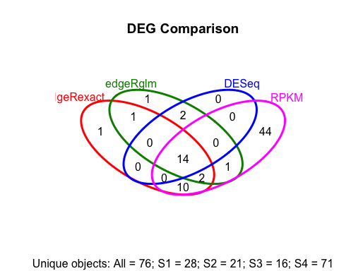

```r
source("http://faculty.ucr.edu/~tgirke/Documents/R_BioCond/My_R_Scripts/overLapper.R")
setlist <- list(edgeRexact=rownames(edge2foldpadj), edgeRglm=rownames(edgeglm2foldpadj), DESeq=as.character(res2foldpadj[,1]), RPKM=rownames(degs2fold))
OLlist <- overLapper(setlist=setlist, sep="_", type="vennsets")
counts <- sapply(OLlist$Venn_List, length)
vennPlot(counts=counts, mymain="DEG Comparison")
```

Number of common genes among all 4 methods: 14

## 6.6 Heatmap of Top Ranking DEGs

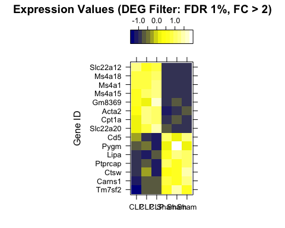

```r
library(lattice); library(gplots)
y <- countDFrpkm[rownames(edgeglm2foldpadj)[1:15],]
colnames(y) <- targets$Factor
y <- t(scale(t(as.matrix(y))))
y <- y[order(y[,1]),]
levelplot(t(y), height=0.2, col.regions=colorpanel(40, "darkblue", "yellow", "white"), main="Expression Values (DEG Filter: FDR 1%, FC > 2)", colorkey=list(space="top"), xlab="", ylab="Gene ID")
```

References

Pepke, Shirley. 2009. “Computation for ChIP-Seq and RNA-Seq Studies.” *Nat Methods* 6 (11). Nature Publishing Group: S22–32. doi:10.1038/nmeth.1371. http://www.nature.com/nmeth/journal/v6/n11s/full/nmeth.1371.html.

Wang, Martin JA. 2011. “Next-Generation Transcriptome Assembly.” *Nat Rev Genet* 12 (10). Nature Publishing Group: 671–82. doi:10.1038/nrg3068. http://www.nature.com/nrg/journal/v12/n10/full/nrg3068.html.